# Project 3: LTI System Response to Random Input

2025, Rayhan R. Zamzamy, et al.

In this experiment, we evaluate how a linear time-invariant (LTI) system responds to a random input signal. The system is implemented in Moving Average (MA) filters. We simulate the LTI system and measure the characteristics of its output signal, including mean, power, autocorrelation, and power spectral density (PSD). This experiment demonstrates the frequency-selective and memory-related effects of LTI systems on stochastic input signals.

## Preparation

```r
# Set the seed for reproducibility
set.seed(52)
```

## 1. Generate a Random Input Signal

We simulate a white Gaussian noise signal as the random input to the system.

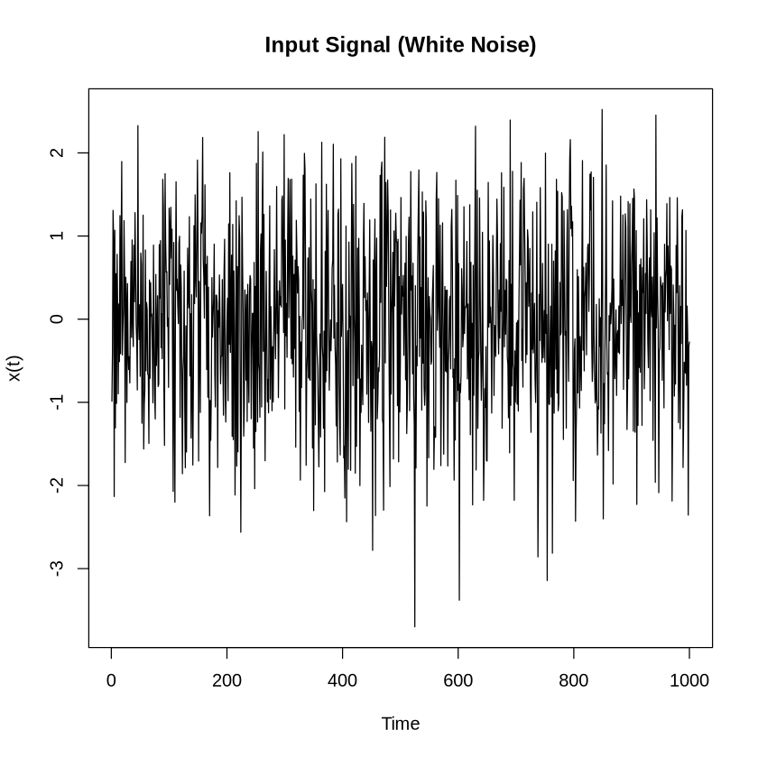

```r
n <- 1000
x <- rnorm(n, mean = 0, sd = 1)

# Plot the white noise signal
plot.ts(x, main = "Input Signal (White Noise)", ylab = "x(t)")
```

## 2. Define the LTI System

We define the LTI system as a Moving Average (MA) filter with the following transfer function:

$$ H(z) = \frac{1}{3}(1 + z^{-1} + z^{-2}) $$

And the frequency response defined as:

$$ H(e^{j\omega}) = \frac{1}{3} \left(1 + e^{-j\omega} + e^{-j2\omega} \right) $$

This is a simple FIR low-pass filter. We will visualize:

- Magnitude response
- Phase response

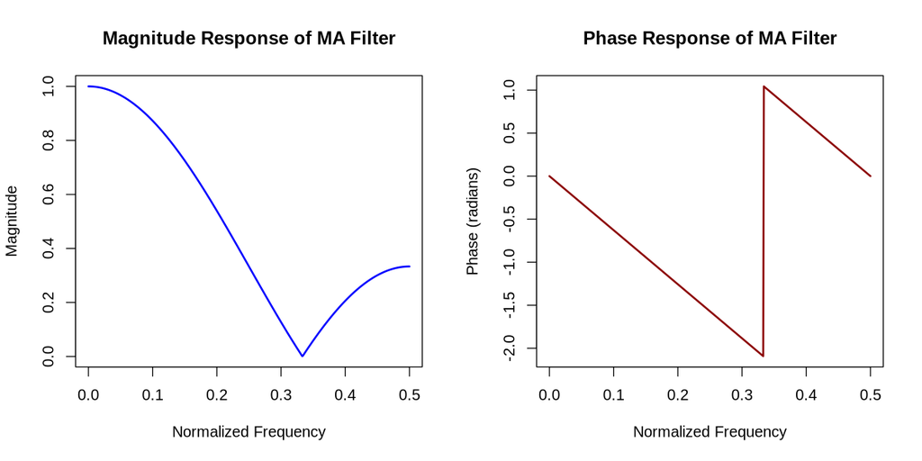

```r
# Define LTI filter coefficients: MA with equal weights
b <- rep(1/3, 3)

# Frequency response of the system
freq_response <- fft(c(b, rep(0, n - length(b))))
freq_bins <- seq(0, 0.5, length.out = 501)

# Plot frequency response
par(mfrow = c(1, 2))
options(repr.plot.width = 10, repr.plot.height = 5)

plot(freq_bins, Mod(freq_response[1:501]), type = "l", col = "blue", lwd = 2,
     main = "Magnitude Response of MA Filter",
     xlab = "Normalized Frequency", ylab = "Magnitude")
plot(freq_bins, Arg(freq_response[1:501]), type = "l", col = "darkred", lwd = 2,
     main = "Phase Response of MA Filter",
     xlab = "Normalized Frequency", ylab = "Phase (radians)")
```

## 3. Simulate LTI System with the Random Input

We apply the MA filter to the white noise input signal.

A data.frame: 6 × 2

|  | input <dbl> | output <dbl> |
| --- | --- | --- |
| 1 | -0.9861909 | NA |
| 2 | -0.3948552 | NA |
| 3 | 1.3085153 | -0.02417694 |
| 4 | 0.9547600 | 0.62280670 |
| 5 | -2.1330788 | 0.04339883 |
| 6 | 1.0689697 | -0.03644970 |

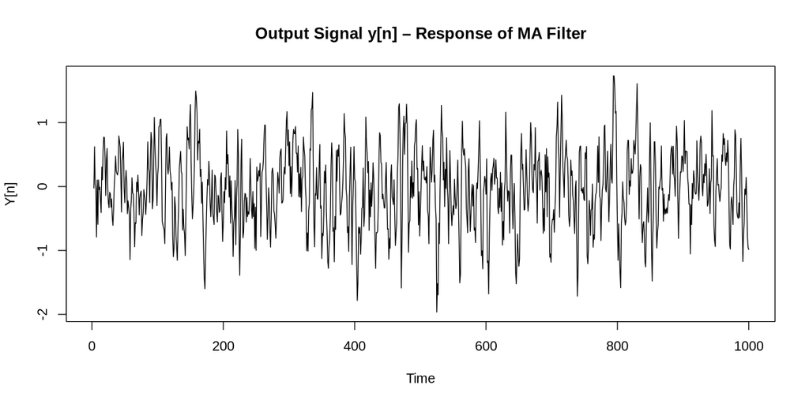

```r
# Simulate LTI system output
y <- filter(x, filter = b, sides = 1)

# Plot the output signal
plot.ts(y, main = "Output Signal y[n] – Response of MA Filter", ylab = "Y[n]")

# Save to a file
write.csv(data.frame(input = x, output = y), "ma_filter_output.csv", row.names = FALSE)

# Preview
head(data.frame(input = x, output = y))
```

## 4. Analyze Data

```
== Summary Statistics for LTI Output ==
  Quantity   Simulated Theoretical
1     Mean -0.03671001   0.0000000
2    Power  0.35932738   0.3333333

== ACF Comparison of Output y[n] ==
  Lag ACF_Simulated ACF_Theoretical
1   0        1.0000          0.3333
2   1        0.6766          0.2222
3   2        0.3677          0.1111
4   3        0.0313          0.0000

== PSD Comparison (First 5 Freq) ==
   Freq PSD_Sim PSD_Theo
1 0.001  0.6080   1.0000
2 0.002  0.1325   1.0000
3 0.003  0.0003   0.9999
4 0.004  0.2891   0.9998
5 0.005  3.8939   0.9996
```

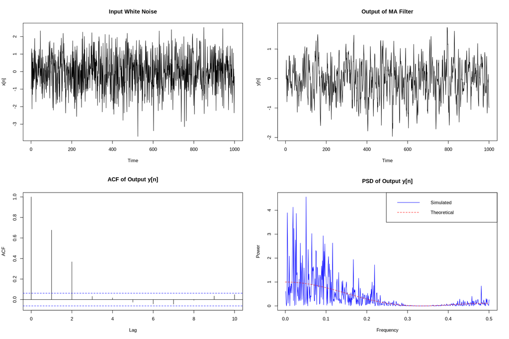

```r
y_valid <- y[!is.na(y)]
x_valid <- x[1:length(y_valid)]

# Output statistics (simulated & theoretical)
mean_y <- mean(y_valid)
power_y <- mean(y_valid^2)
mean_y_theo <- 0
power_y_theo <- sum(b^2)

# ACF (simulated & theoretical)
acf_y <- acf(y_valid, lag.max = 10, plot = FALSE)$acf[,,1]

acf_y_theo <- numeric(11)
for (k in 0:10) {
  if (k <= (length(b) - 1)) {
    acf_y_theo[k + 1] <- sum(b[1:(length(b) - k)] * b[(k + 1):length(b)])
  } else {
    acf_y_theo[k + 1] <- 0
  }
}

# PSD (simulated & theoretical)
spec_y <- spectrum(y_valid, plot = FALSE)

omega <- seq(0, pi, length.out = 512)
H <- b[1]*exp(-1i*omega*0) + b[2]*exp(-1i*omega*1) + b[3]*exp(-1i*omega*2)
psd_y_theo <- Mod(H)^2  # since Sxx = 1

# Tables
summary_y <- data.frame(
  Quantity = c("Mean", "Power"),
  Simulated = c(mean_y, power_y),
  Theoretical = c(mean_y_theo, power_y_theo)
)

acf_table_y <- data.frame(
  Lag = 0:3,
  ACF_Simulated = round(acf_y[1:4], 4),
  ACF_Theoretical = round(acf_y_theo[1:4], 4)
)

psd_table_y <- data.frame(
  Freq = round(spec_y$freq[1:5], 4),
  PSD_Sim = round(spec_y$spec[1:5], 4),
  PSD_Theo = round(psd_y_theo[1:5], 4)
)

# Plots
par(mfrow = c(2, 2))
options(repr.plot.width = 15, repr.plot.height = 10)

plot.ts(x, main = "Input White Noise", ylab = "x[n]")
plot.ts(y, main = "Output of MA Filter", ylab = "y[n]")
acf(y_valid, lag.max = 10, main = "ACF of Output y[n]")
plot(spec_y$freq, spec_y$spec, type = "l", col = "blue",
     main = "PSD of Output y[n]", xlab = "Frequency", ylab = "Power")
lines(omega/(2*pi), psd_y_theo, col = "red", lty = 2)
legend("topright", legend = c("Simulated", "Theoretical"), col = c("blue", "red"), lty = 1:2)

# Print Tables
cat("\n== Summary Statistics for LTI Output ==\n")
print(summary_y)

cat("\n== ACF Comparison of Output y[n] ==\n")
print(acf_table_y)

cat("\n== PSD Comparison (First 5 Freq) ==\n")
print(psd_table_y)
```

## Summary

In this experiment, we examined the response of a Linear Time-Invariant (LTI) system to a white Gaussian noise input. The LTI system was implemented as a Moving Average (MA) filter with the transfer function:

$$ H(z) = \frac{1}{3}(1 + z^{-1} + z^{-2}) $$

In the process, We:

- Simulated the output of the LTI system when driven by white noise.
- Analyzed the output signal's mean, power, ACF, and PSD.
- Compared simulated results with theoretical expectations.
- Observed the system's frequency response characteristics.